# IODS course project

Jussi-Pekka Martikainen

## Week1 - About the course: Introduction to Open Data Science

The course learning objectives are:

- to understand the principles and advantages of using open research tools with open data
- to understand the possibilities of reproducible research
- to learn how to use R, RStudio, RMarkdown and GitHub
- to know how to learn more about the above open software tools
- to know how to apply certain methods of data science (data driven statistics)

[Link](https://github.com/ittobor/IODS-project) to my GitHub repository for this course.

# Week2 - Regression and model validation

I prepared myself for this weeks topic by completing DataCamp exercise on “Regression and model validation”.

## Data Wrangling

For the data wrangling part of this weeks exercises I mostly used the methods learned from the DataCamp exercise. I learned the basics of data wrangling in R and know how to find out more methods/tools and how to use them to wrangle the data.

My source code used in the wrangling is [here](https://github.com/ittobor/IODS-project/blob/master/data/create_learning2014.R).

Basically, here are the main points what is done in the code:

- Original dataset is read from given web source.
- Structure of the data is explored with `str` and `dim`.
- `learning2014` is created as new empty data.frame to store the required variables.
- Variables `gender`, `age`, `attitude` and `points` are simply copied from the orignal dataset to `learning2014`.
- The question variables from the original dataset are combined and stored as scaled variables in to `learning2014`. dplyr library is used here.
- Observations with `points < 1` are filtered out from `learning2014`.
- learning2014` data.frame is saved as a text-file with same format as the original dataset.

The dataset (`learning2014.txt`) that the code created can be found from [here](https://github.com/ittobor/IODS-project/blob/master/data/learning2014.txt).

## Data Analysis

With `dim` function we learn the dimension of the input dataset. That is the function returns the number of columns and rows.

```r
dim(learning2014)
```

```
## [1] 166   7
```

With `str` function we learn about the structure of the input dataset. Basically we get to know the number of observations (rows) and variables (columns) in the dataset. The output summary from the function lists the variables, the type of each variable vector and few example values from the vector.

```r
str(learning2014)
```

```
## 'data.frame':    166 obs. of  7 variables:
##  $ gender  : Factor w/ 2 levels "F","M": 1 2 1 2 2 1 2 1 2 1 ...
##  $ age     : int  53 55 49 53 49 38 50 37 37 42 ...
##  $ attitude: int  37 31 25 35 37 38 35 29 38 21 ...
##  $ points  : int  25 12 24 10 22 21 21 31 24 26 ...
##  $ deep    : num  3.58 2.92 3.5 3.5 3.67 ...
##  $ surf    : num  2.58 3.17 2.25 2.25 2.83 ...
##  $ stra    : num  3.38 2.75 3.62 3.12 3.62 ...
```

I use `ggpairs` to show detailed graphical overview of the input dataset, just like it was done in the DataCamp course for this weeks exercises. `ggpairs`creates matrix of plots from the given dataset. With aesthetics mapping we are instructing the colors to be based `gender` variable and the transparency is controlled with value give to alpha parameter. Parameter lower controls the type of plots for lower section of the plot matrix. All plots are between pair of variables in the `learning2014` dataset and each are categorized based on `gender` variable. Above the diagonal with density plots there are the correlation coeffiecients of the pairs as a whole and then categorized based on `gender` variable.

From the plots we can see that nearly 2/3 of the observations are from females, thus 1/3 are from males. When we look at the single variables categorized by gender, we see that variable `attitude` deviates the most between sexes. Also females tend to be more younger than males based on variable `age`. There is also deviations between female and male in the combined question variables, where `surface` question group deviates the most and `strategy` to some extent.

When we look at the correlation coefficients we see that `points` and `attitude` correlate in agreement the most (0.437) in the dataset variables, with equally high for both females and males. Then `deep` and `surf` combined question variables correlate in disagreement the most (-0.324), with amongst all males the variables disagree (-0.622) clearly more than amongst females (-0.087). Then there are several pairs that have similar correlation in agreement (`age`,`strategic`), (`deep`,`attitude`) and (`points`,`strategic`), and several pairs that have similar correlation in disagreement (`strategic`,`surface`), (`points`,`surface`), (`attitude`,`surface`) and (`age`,`surface`).

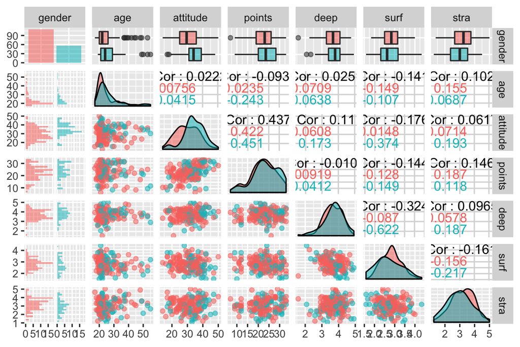

```r
ggpairs(learning2014,
        mapping = aes(col = gender, alpha = 0.3),
        lower = list(combo = wrap("facethist", bins = 20)))
```

With `summary` command we can see statistics of each variable in the dataset `learning2014`. For categorical variable `gender` we only get number of values for females and males. Then for each of the numerical varibles we get minimum, maximum, mean, median, 1st and 3rd quantiles.

```r
summary(learning2014)
```

```
##  gender       age           attitude         points           deep
##  F:110   Min.   :17.00   Min.   :14.00   Min.   : 7.00   Min.   :1.583
##  M: 56   1st Qu.:21.00   1st Qu.:26.00   1st Qu.:19.00   1st Qu.:3.333
##          Median :22.00   Median :32.00   Median :23.00   Median :3.667
##          Mean   :25.51   Mean   :31.43   Mean   :22.72   Mean   :3.680
##          3rd Qu.:27.00   3rd Qu.:37.00   3rd Qu.:27.75   3rd Qu.:4.083
##          Max.   :55.00   Max.   :50.00   Max.   :33.00   Max.   :4.917
##       surf            stra
##  Min.   :1.583   Min.   :1.250
##  1st Qu.:2.417   1st Qu.:2.625
##  Median :2.833   Median :3.188
##  Mean   :2.787   Mean   :3.121
##  3rd Qu.:3.167   3rd Qu.:3.625
##  Max.   :4.333   Max.   :5.000
```

```
##
## Call:
## lm(formula = points ~ attitude + stra + age, data = learning2014)
##
## Residuals:
##      Min       1Q   Median       3Q      Max
## -18.1149  -3.2003   0.3303   3.4129  10.7599
##
## Coefficients:
##             Estimate Std. Error t value Pr(>|t|)
## (Intercept) 10.89543    2.64834   4.114 6.17e-05 ***
## attitude     0.34808    0.05622   6.191 4.72e-09 ***
## stra         1.00371    0.53434   1.878   0.0621 .
## age         -0.08822    0.05302  -1.664   0.0981 .
## ---
## Signif. codes:  0 '***' 0.001 '**' 0.01 '*' 0.05 '.' 0.1 ' ' 1
##
## Residual standard error: 5.26 on 162 degrees of freedom
## Multiple R-squared:  0.2182, Adjusted R-squared:  0.2037
## F-statistic: 15.07 on 3 and 162 DF,  p-value: 1.07e-08
```

Model assumptions describe the data generating process. How well the assumptions fit reality the better the model describes the phenomenom of interest. With linear regression linearity is assumed: target is modelled as a linear combination of model parameters. Usually is also assumed that the errors are normally distributed, errors are not correlated and have constant variance, and that size of given error does not depend on the explanatory variables.

With QQ-plot of the residuals we can explore the assumption that of errors of the model are normally distributed. Here we in the 2nd plot we have a QQ-plot of the model and we can see that the majority of the explanatory variables fit well to the line and to the normality assumption.

The constant variance assumption can be explored with simple scatter plot of residuals versus model predictions. Any pattern on the scatter plot implies a problem with the assumption. Here the scatter plot is the 1st plot, and I must say that it is a bit difficult to say that is there a pattern (problem) in the plot especially when looking at with less fitted values and more fitted values. Then again, in between of less and more fitted values it is well scattered.

Leverage measures how much impact a single observation has on the model and residuals vs. leverage plot helps identifying observations with high impact. Here the last plot is the residuals vs. leverage plot. Again it is little hard for me to tell, but my interpretation is that there is no single outstanding observation that would drag the model.

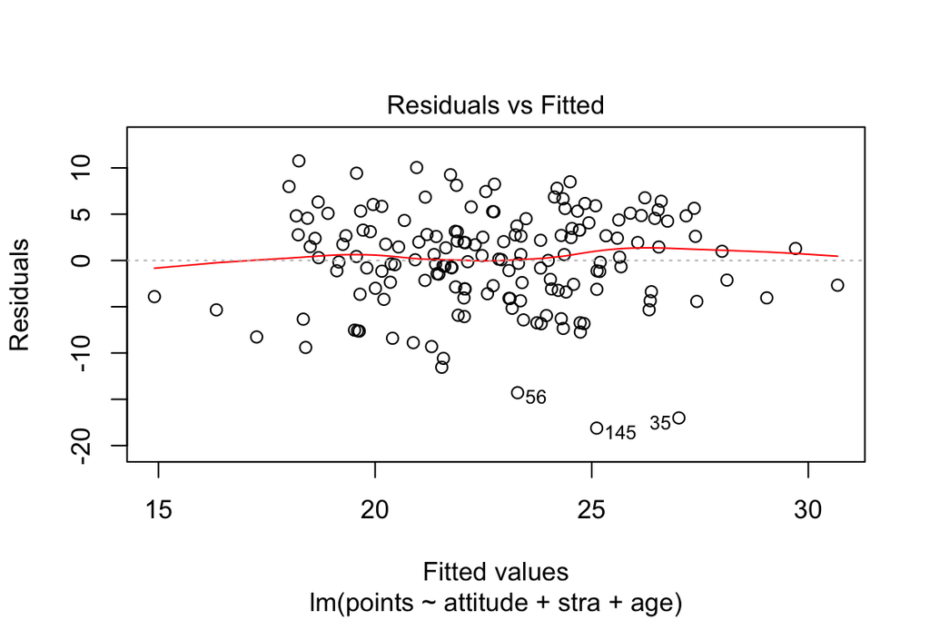

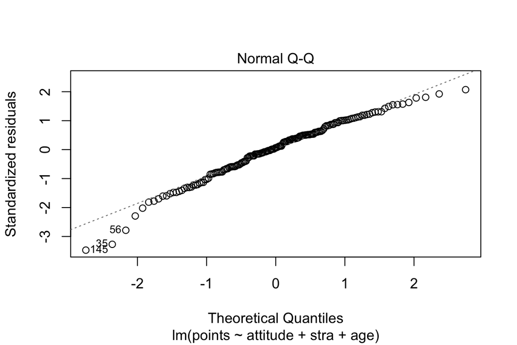

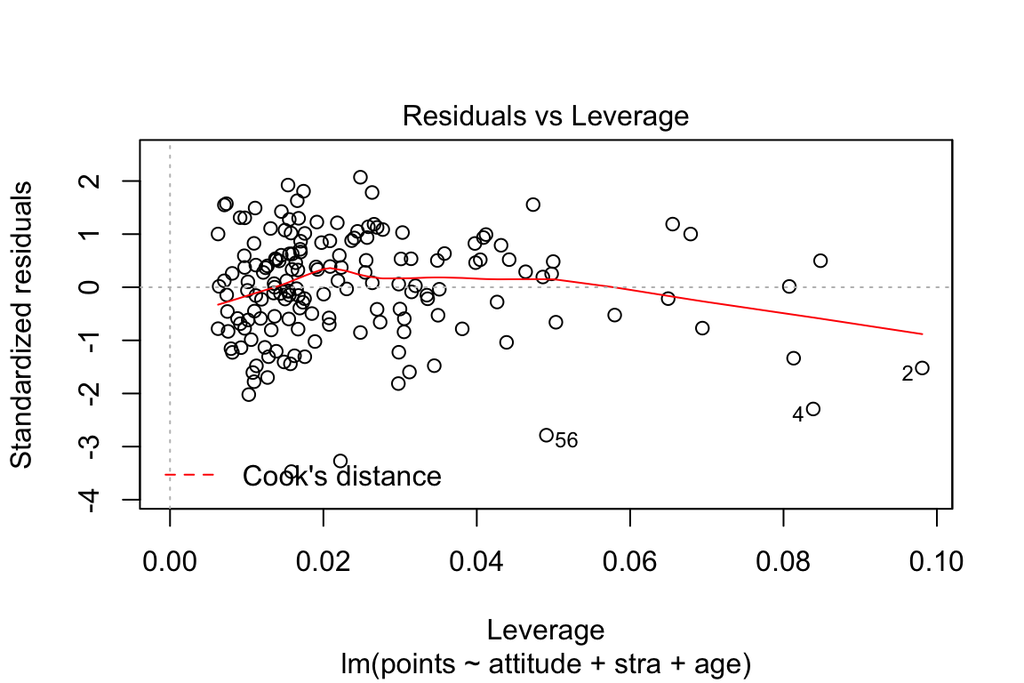

# Week3 - Logistic Regression

I prepared myself for this weeks topic by completing DataCamp exercise on “Logistic Regression”.

## Data Wrangling

As I did last week, for the data wrangling part of this weeks exercises I mostly used the methods learned from the DataCamp exercise. I learned about joining datasets and doing data mutations.

My source code used in the wrangling is [here](https://github.com/ittobor/IODS-project/blob/master/data/create_alc.R).

Basically, here are the main points what is done in the code:

- Initial dataset is acquired and extracted manually from given web source.
- Two data sets are read in and combined as one, since they contain answers from same students, by joining them based on variables: `school`,`sex`,`age`,`address`,`famsize`,`Pstatus`,`Medu`,`Fedu`,`Mjob`,`Fjob`,`reason`,`nursery`,`internet`
- The columns not used in join are combined by taking rounded avarage of numerical values and by selecting the first value of not numeric values
- `alc_use` variable was generated to indicate alcohol use (avarage of daily and weekly consumption)
- `high_use` variables was generated to indicate high use of alcohol (true is `alc_use` > 2)

The dataset (`alc.csv`) that the code created can be found from [here](https://github.com/ittobor/IODS-project/blob/master/data/alc.csv).

## Data Analysis

### Step 1 - New markdown file

Step one was to create chapter3.Rmd to inject this content to the diary as a child of subscipts in index.Rmd.

### Step 2 - Combined dataset and attributes

The combined dataset contains the data from two Portuguese schools and were originally gathered from school reports and questionnaires. The data was collected initally in two datasets, one regarding student performance in mathemathics and one regarding student performance in Portuguese language. In addition to section Data Wrangling, in which the join criteria and additionally created variables are discussed, you can find more information about the variables in [here](https://archive.ics.uci.edu/ml/datasets/Student+Performance).

Dimensions and the column (variable) names of the combined dataset:

```r
dim(alc)
```

```
## [1] 382  35
```

```r
colnames(alc)
```

```
##  [1] "school"     "sex"        "age"        "address"    "famsize"
##  [6] "Pstatus"    "Medu"       "Fedu"       "Mjob"       "Fjob"
## [11] "reason"     "nursery"    "internet"   "guardian"   "traveltime"
## [16] "studytime"  "failures"   "schoolsup"  "famsup"     "paid"
## [21] "activities" "higher"     "romantic"   "famrel"     "freetime"
## [26] "goout"      "Dalc"       "Walc"       "health"     "absences"
## [31] "G1"         "G2"         "G3"         "alc_use"    "high_use"
```

Column (variable) types of the combined dataset:

```r
glimpse(alc)
```

```
## Observations: 382
## Variables: 35
## $ school     <fct> GP, GP, GP, GP, GP, GP, GP, GP, GP, GP, GP, GP, GP,...
## $ sex        <fct> F, F, F, F, F, M, M, F, M, M, F, F, M, M, M, F, F, ...
## $ age        <int> 18, 17, 15, 15, 16, 16, 16, 17, 15, 15, 15, 15, 15,...
## $ address    <fct> U, U, U, U, U, U, U, U, U, U, U, U, U, U, U, U, U, ...
## $ famsize    <fct> GT3, GT3, LE3, GT3, GT3, LE3, LE3, GT3, LE3, GT3, G...
## $ Pstatus    <fct> A, T, T, T, T, T, T, A, A, T, T, T, T, T, A, T, T, ...
## $ Medu       <int> 4, 1, 1, 4, 3, 4, 2, 4, 3, 3, 4, 2, 4, 4, 2, 4, 4, ...
## $ Fedu       <int> 4, 1, 1, 2, 3, 3, 2, 4, 2, 4, 4, 1, 4, 3, 2, 4, 4, ...
## $ Mjob       <fct> at_home, at_home, at_home, health, other, services,...
## $ Fjob       <fct> teacher, other, other, services, other, other, othe...
## $ reason     <fct> course, course, other, home, home, reputation, home...
## $ nursery    <fct> yes, no, yes, yes, yes, yes, yes, yes, yes, yes, ye...
## $ internet   <fct> no, yes, yes, yes, no, yes, yes, no, yes, yes, yes,...
```

[output cut: 22 more lines]

### Step 3 - Variables to study in relations with alcohol consumption

My hypothesis to study is how time consumption is related with alcohol consumption. The idea being that if you spend your time with activities you would not have time to consume alcohol and vice versa. My choice of variables are in sense time consuming variables: `freetime`, `goout`, `studytime` and `traveltime`.

- `traveltime` - Home to school travel time. My intuition here is this would be a factor to decrease alcohol consumption.
- `studytime` - Weekly study time. My intuition here is this would be a factor to decrease alcohol consumption.
- `freetime` - Free time after school. My intuition here is this would be a factor to increase alcohol consumption.
- `goout` - Going out with friends. My intuition here is this would be a factor to increase alcohol consumption.

### Step 4 - Numerical and graphical exploration on chosen variables

Here I use `ggpairs`, from last week, to visualize the chosen variables together with the variable `high_use`. From the diagram we get quickly a good overview of the relations of the variables between themselves and with the variable `high_use`. By looking at the correlation coefficients we can observe that there is not much correlation between the chosen variables. We could say that `freetime` and `goout` mildly correlate positively, meaning that you would go out with friends during your freetime which makes common sense. Also that `traveltime` and `studytime` mildly correlate negatively, the same with `freetime` and `studytime`, meaning that travel time between school and home, also freetime, is not used for studying. My interpretation is that the low correlation between the chosen variables could tell that variables are not interfering with each other and be independently a factor to increase or decrease alcohol consumption. And that can be seen in favor of my hypothesis.

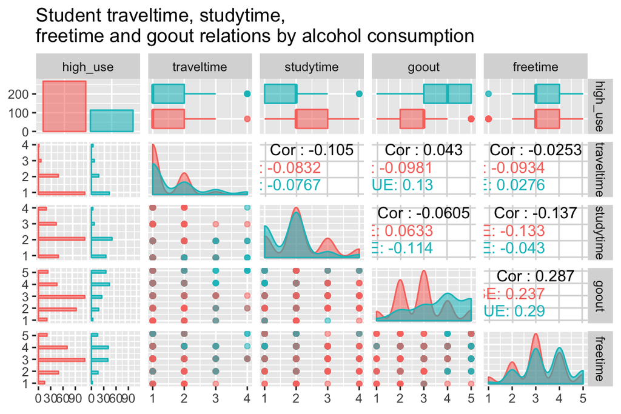

Looking at the box and bar plots of each chosen variable divided by alcohol we can see that `traveltime` and `freetime` are quite identically distributed both in terms of high and low alcohol consumption. When looking at the high alcohol consumption with `freetime` it seems that the hight alcohol consumption increases more when freetime increases, whereas low alcohol consumption increases less when freetime increases.

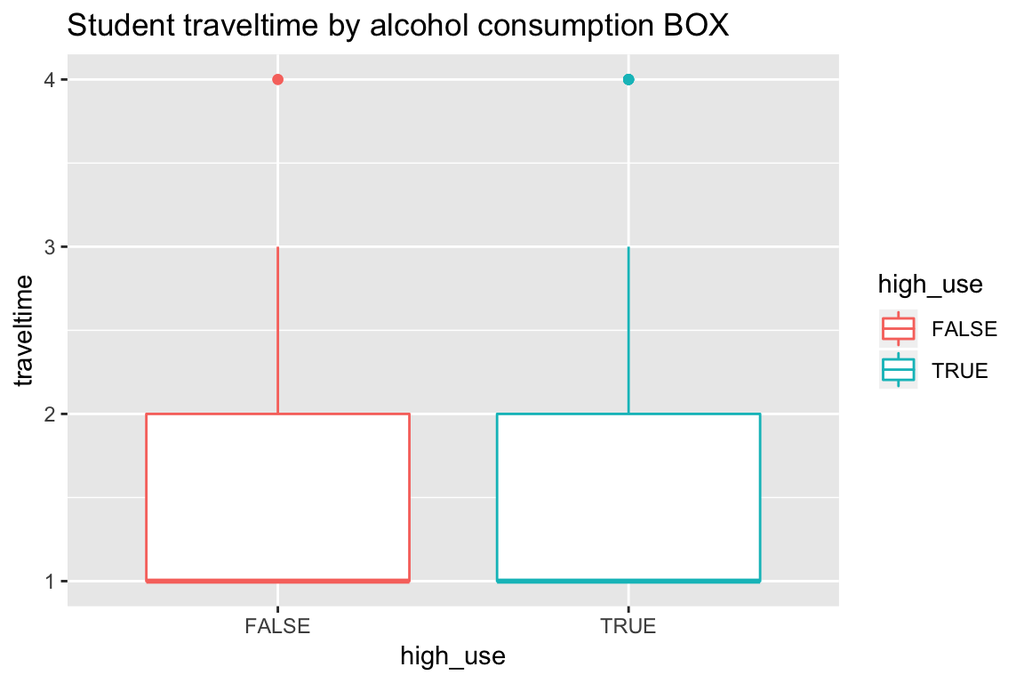

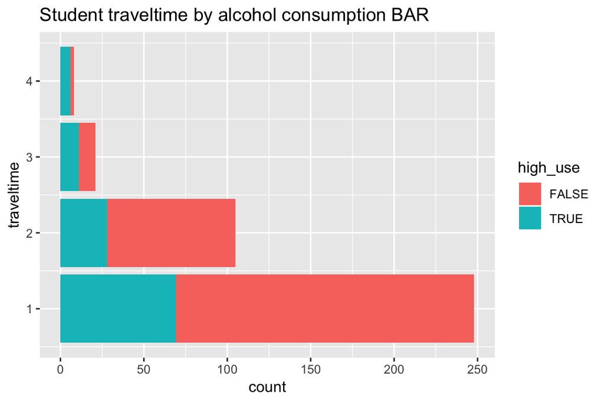

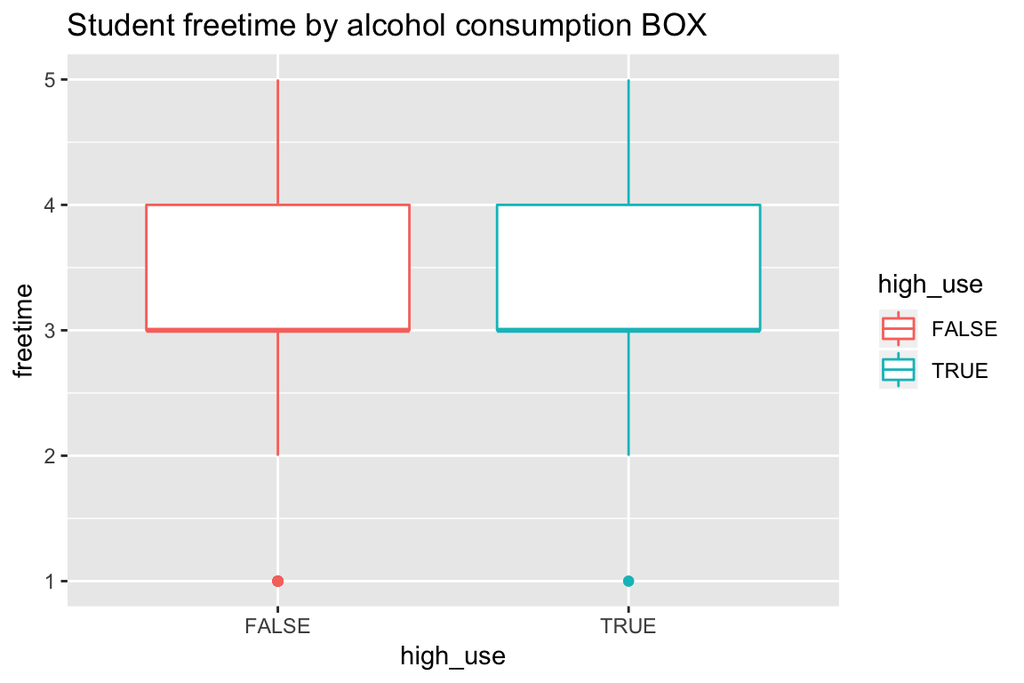

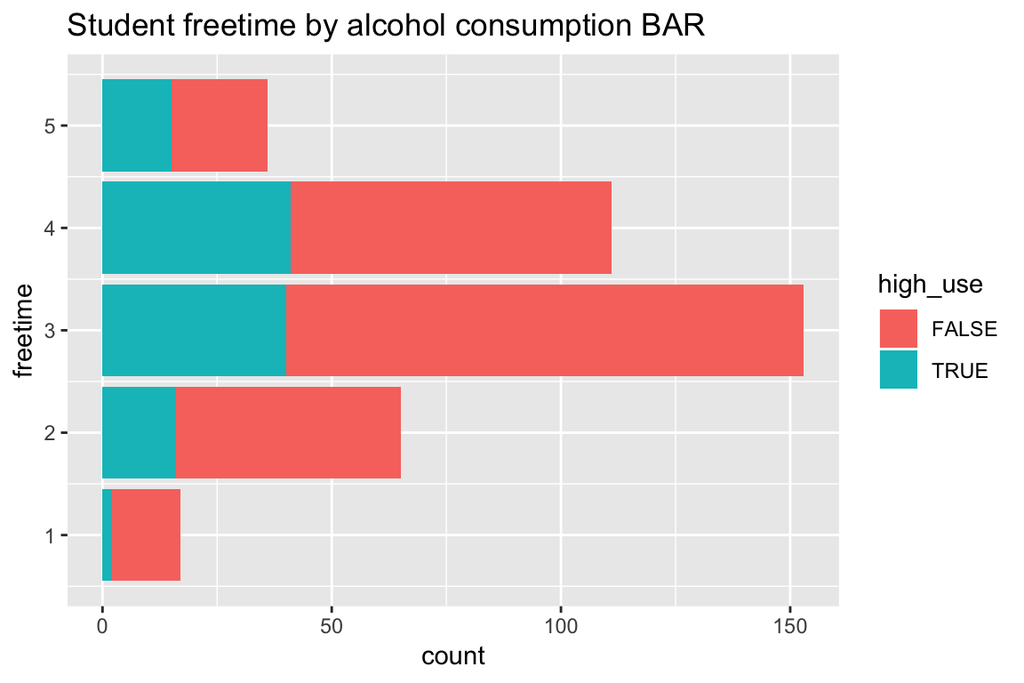

With `studytime` and `goout` the distributions differ more in terms of high and low alcohol consumption. When looking at the high alcohol consumption with `studytime` it seems that the high alcohol consumption increases more when studytime decreases compared to low alcohol consumption. Also high alcohol consumption increases more when go out time with friends increases compared to low alcohol consumption.

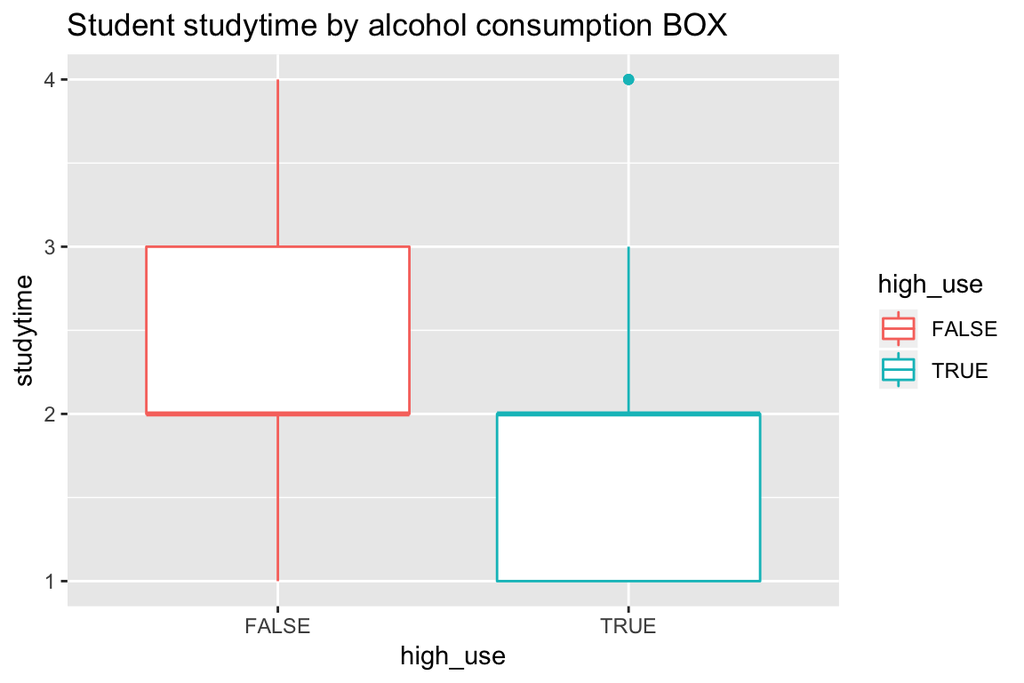

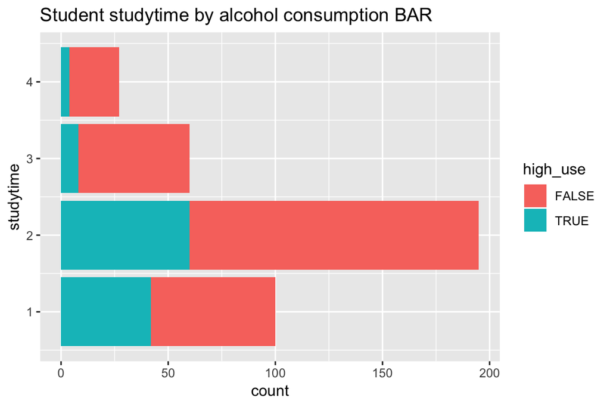

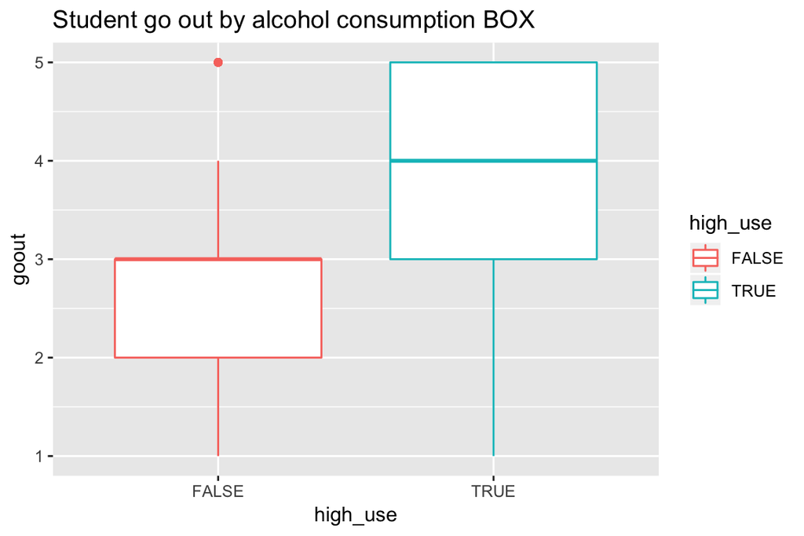

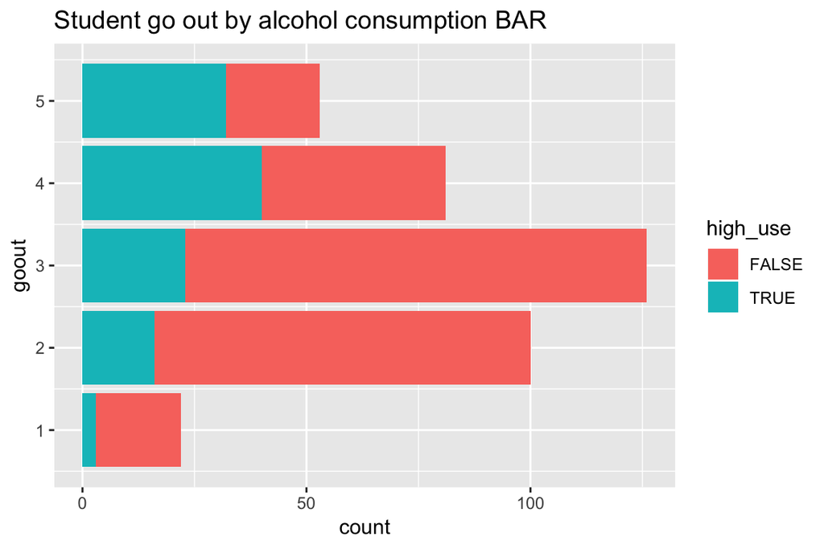

### Step 5 - Statistical exploration with logistic regression

Here we use logistic regression to statistically explore the relationship between chosen variables and the binary high/low alcohol consumption.

```
##
## Call:
## glm(formula = high_use ~ studytime + goout + traveltime + freetime,
##     family = "binomial", data = alc)
##
## Deviance Residuals:
##     Min       1Q   Median       3Q      Max
## -1.5805  -0.7670  -0.5270   0.8878   2.4724
##
## Coefficients:
##             Estimate Std. Error z value Pr(>|z|)
## (Intercept)  -2.9531     0.7013  -4.211 2.54e-05 ***
## studytime    -0.5612     0.1655  -3.391 0.000697 ***
## goout         0.7206     0.1212   5.947 2.73e-09 ***
## traveltime    0.3619     0.1752   2.066 0.038868 *
## freetime      0.0921     0.1354   0.680 0.496389
## ---
## Signif. codes:  0 '***' 0.001 '**' 0.01 '*' 0.05 '.' 0.1 ' ' 1
##
## (Dispersion parameter for binomial family taken to be 1)
##
##     Null deviance: 465.68  on 381  degrees of freedom
## Residual deviance: 396.18  on 377  degrees of freedom
## AIC: 406.18
##
## Number of Fisher Scoring iterations: 4
```

From the summary we can see the distribution of deviance residuals for the individual cases used in the model. The table of coeffiecients shows the coefficients and its standard error for each variable. The coefficients tell the change in the log odds of the outcome for a one unit increase in the predictor variable (e.g. one unit change in `goout` gives the log odds of `high_use` increase by 0.7206). From the p-values we can see that the probability of each variable NOT being relevant (so low score here is good). From the significance indicators we can tell that `studytime`, `goout` and `traveltime` are statistically significant, but `freetime` is not.

```
##                    OR      2.5 %    97.5 %
## (Intercept) 0.0521788 0.01274364 0.2006731
## studytime   0.5705061 0.40821453 0.7826192
## goout       2.0556712 1.63108393 2.6258521
## traveltime  1.4359821 1.01912982 2.0303214
## freetime    1.0964726 0.84079237 1.4317362
```

### Step 6 - Predicative power of the model

First we need to re-fit the model by taking out the statistically not significant `freetime` variable.

```
##
## Call:
## glm(formula = high_use ~ studytime + goout + traveltime, family = "binomial",
##     data = alc)
##
## Deviance Residuals:
##     Min       1Q   Median       3Q      Max
## -1.5318  -0.7679  -0.5214   0.8604   2.4526
##
## Coefficients:
##             Estimate Std. Error z value Pr(>|z|)
## (Intercept)  -2.6967     0.5878  -4.588 4.47e-06 ***
## studytime    -0.5716     0.1650  -3.464 0.000532 ***
## goout         0.7431     0.1172   6.343 2.25e-10 ***
## traveltime    0.3559     0.1746   2.039 0.041486 *
## ---
## Signif. codes:  0 '***' 0.001 '**' 0.01 '*' 0.05 '.' 0.1 ' ' 1
##
## (Dispersion parameter for binomial family taken to be 1)
##
##     Null deviance: 465.68  on 381  degrees of freedom
## Residual deviance: 396.64  on 378  degrees of freedom
## AIC: 404.64
##
## Number of Fisher Scoring iterations: 4
```

Then we use the model to predict probabilities for the date that was used to train the model. Based on the probabilities we make predictions for the training data observations so that `probability > 0.5` is high alcohol consumption, otherwise low. In the first table below we can see the counts of the true values of `high_use` and of the predictions. And in the second table are the proportions of the same. From these we can compute that the model gets it (0.63874346 + 0.11780105 = 0.75654451) ~76% times correct, meaning the training error being ~24%. The model gets 91% of the true low alcohol consumption observations correct, but only ~39% of the true high alcohol consumption observations correct.

```
##         prediction
## high_use FALSE TRUE Sum
##    FALSE   244   24 268
##    TRUE     69   45 114
##    Sum     313   69 382
```

```
##         prediction
## high_use      FALSE       TRUE        Sum
##    FALSE 0.63874346 0.06282723 0.70157068
##    TRUE  0.18062827 0.11780105 0.29842932
##    Sum   0.81937173 0.18062827 1.00000000
```

As as performance comparison to a simple guessing strategy, with weights 2/3 to low alcohol consumption and 1/3 to high alcohol consumption, we can see that the model beats this guessing strategy. The results from the simple guessing strategy is below. Simple guessing strategy get ~59% correct from the true totals, ~70% of the true low alcohol consumption and ~32% of the true high alcohol consumption. (Note: Since guessing strategy is based on randomizer there might be slight changes on percentages written above and how many time this rmarkdown code is run after what I had written)

```
##         prediction
## high_use   0   1 Sum
##    FALSE 187  81 268
##    TRUE   77  37 114
##    Sum   264 118 382
```

```
##         prediction
## high_use          0          1        Sum
##    FALSE 0.48952880 0.21204188 0.70157068
##    TRUE  0.20157068 0.09685864 0.29842932
##    Sum   0.69109948 0.30890052 1.00000000
```

Here is also graphical visualization of the actual and predicted values.

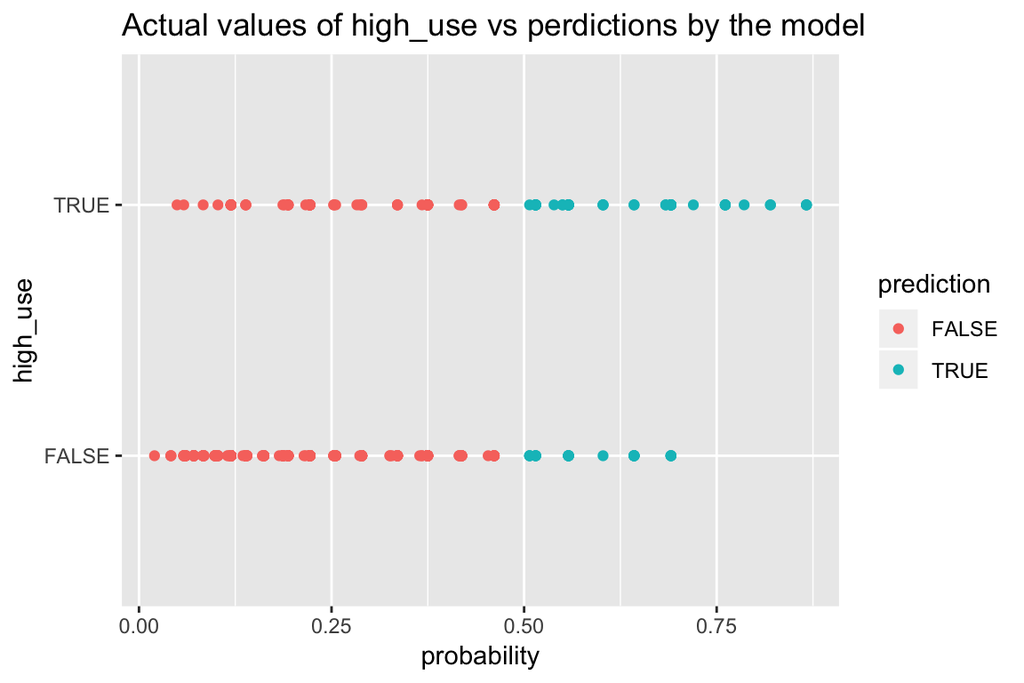

### Step 7 - 10-fold cross-validation BONUS

For the 10-fold cross-validation we need to define a loss function. I use the same definition of loss function as was done in the Data Camp exercises. Here is the error-rate of the above trained model computed with the loss function.

```
## [1] 0.2434555
```

And here is the error-rate of the trained model wih 10-fold cross-validation. As you can see the model slightly outperforms the model used in Data Camp exercise.

```
## [1] 0.2539267
```

### Step 8 - Cross-validation of performance of different logistic regression models SUPERBONUS

In this part of the exercise set I used only variables that are of numeric type (type:int). There are 14 such variables. I use for loop to add a predictor in one-by-one fashion and do the cross-validation step to store the error in betweens. Unfortunately my plotting skills are poor and I was not able to flip the value-labels of x-axis (was able to flip the “curve” but decided not to since it would make it more confusing), hence the errors are represented in this plot in increasing number of predictors order.

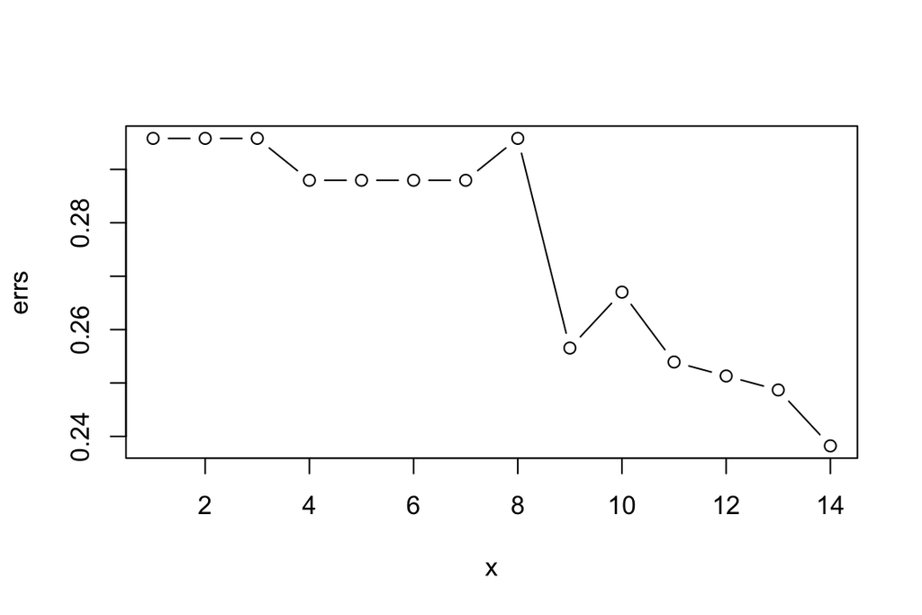

```
##  [1] 0.2958115 0.2958115 0.2958115 0.2879581 0.2879581 0.2879581 0.2879581
##  [8] 0.2958115 0.2565445 0.2670157 0.2539267 0.2513089 0.2486911 0.2382199
```